# practica-4

## Pago por contratación de medios en Zaragoza (2011-2017)

```python
!pip install pandas
```

```python
import pandas as pd
```

```python
url = "http://www.zaragoza.es/contenidos/gobierno-abierto/transparencia/Gasto_mediacion_prensa_2011-2017.csv"
```

```python
df_medios= pd.read_csv(url,delimiter=";")
df_medios
```

|  | Unnamed: 0 | GASTOS CONTRATO MEDIACIÓN AÑOS 2011 A 2017 | Unnamed: 2 | Unnamed: 3 | Unnamed: 4 | Unnamed: 5 | Unnamed: 6 | Unnamed: 7 | Unnamed: 8 |
| --- | --- | --- | --- | --- | --- | --- | --- | --- | --- |
| 0 | Tipo | medio de comunicación | 2011 | 2012 | 2013 | 2014 | 2015 | 2016 | 2017 |
| 1 | TABLÓN DE RADIO | ARAGÓN RADIO | 4.962,74 € | 6.306,40 € | 6.306,28 € | 6.306,40 € | 4.413,30 € | 5.328,89 € | 0,00 € |
| 2 | TABLÓN DE RADIO | RADIO ZARAGOZA | 31.520,26 € | 31.520,26 € | 31.520,26 € | 31.520,26 € | 31.520,26 € | 31.520,26 € | 31.520,26 € |
| 3 | TABLÓN DE RADIO | ABC PUNTO RADIO | 21.268,15 € | 21.268,17 € | 5.281,05 € | NaN | NaN | NaN | NaN |
| 4 | TABLÓN DE RADIO | COPE | 16.459,63 € | 16.459,63 € | 16.459,63 € | 16.459,63 € | 16.459,63 € | 16.459,63 € | 16.459,63 € |
| 5 | TABLÓN DE RADIO | ONDA CERO | 10.872,20 € | 10.872,21 € | 10.872,21 € | 10.872,21 € | 10.872,20 € | 10.872,20 € | 10.872,20 € |
| 6 | TABLÓN DE RADIO | RADIO EBRO | 7.315,39 € | 7.315,42 € | 7.315,54 € | 7.315,30 € | 7.315,41 € | 7.315,41 € | 7.315,41 € |
| 7 | TABLÓN DE RADIO | RADIO INTERECONOMIA | 3.152,73 € | 5.878,76 € | 1.469,70 € | NaN | NaN | NaN | NaN |
| 8 | TABLÓN DE RADIO | ES RADIO ZARAGOZA | NaN | NaN | 18.112,26 € | 8.838,25 € | 6.644,72 € | 6.644,72 € | 6.644,72 € |
| 9 | TABLÓN DE RADIO | LATINA FM | NaN | 709,47 € | 1.051,73 € | NaN | NaN | NaN | NaN |
| 10 | TABLÓN DE RADIO | OLIMPICA FM | 2.768,67 € | 2.128,41 € | NaN | NaN | NaN | NaN | NaN |
| 11 | TABLÓN DE PRENSA | EL PERIÓDICO DE ARAGÓN | 41.972,04 € | 38.475,53 € | 62.613,77 € | 43.932,76 € | 40.313,13 € | 31.710,73 € | 17.264,40 € |
| 12 | TABLÓN DE PRENSA | HERALDO DE ARAGÓN | 38.832,87 € | 20.567,94 € | NaN | NaN | 0,00 € | 19.021,50 € | 29.577,27 € |
| 13 | ACCIONES ESPECIALES | EL PERIÓDICO DE ARAGÓN | 26.687,28 € | NaN | 8.289,67 € | 15.881,24 € | 40.296,07 € | 27.043,76 € | 8.143,30 € |
| 14 | ACCIONES ESPECIALES | HERALDO DE ARAGON | 59.023,40 € | NaN | 16.125,00 € | 17.291,89 € | 44.026,33 € | 12.561,97 € | 10.205,62 € |
| 15 | ACCIONES ESPECIALES | ABC | 2.662,00 € | NaN | NaN | NaN | NaN | NaN | NaN |
| 16 | ACCIONES ESPECIALES | MARCA | 4.677,86 € | NaN | 3.049,20 € | NaN | NaN | NaN | NaN |
| 17 | ACCIONES ESPECIALES | 20 Minutos | 13.284,35 € | NaN | NaN | 12.170,97 € | NaN | NaN | NaN |
| 18 | ACCIONES ESPECIALES | ADN | 5.357,88 € | NaN | NaN | NaN | NaN | NaN | NaN |
| 19 | ACCIONES ESPECIALES | ARAGON UNIVERSIDAD | 508,20 € | NaN | NaN | NaN | NaN | NaN | NaN |
| 20 | ACCIONES ESPECIALES | ARAGON TV | 13.001,45 € | NaN | NaN | NaN | NaN | NaN | NaN |
| 21 | ACCIONES ESPECIALES | ZTV | 2.420,00 € | NaN | 8.399,94 € | NaN | NaN | NaN | NaN |
| 22 | ACCIONES ESPECIALES | 13 TV | NaN | 12.909,49 € | NaN | NaN | NaN | NaN | NaN |
| 23 | ACCIONES ESPECIALES | SER | 6.753,70 € | NaN | 25.909,08 € | 21.804,20 € | 19.714,29 € | 15.771,38 € | 28.354,19 € |
| 24 | ACCIONES ESPECIALES | COPE | 6.537,57 € | NaN | NaN | 15.750,00 € | 25.837,13 € | 14.031,21 € | 14.535,99 € |
| 25 | ACCIONES ESPECIALES | ONDA CERO | 6.353,88 € | 21.272,53 € | 24.148,39 € | 1.815,00 € | 18.693,29 € | 16.220,05 € | 13.718,94 € |
| 26 | ACCIONES ESPECIALES | ABC RADIO | 3.616,57 € | 6.288,98 € | NaN | NaN | NaN | NaN | NaN |
| 27 | ACCIONES ESPECIALES | RADIO EBRO | 1.488,30 € | 17.366,40 € | NaN | NaN | 2.843,50 € | 6.266,87 € | 9.742,32 € |
| 28 | ACCIONES ESPECIALES | ARAGON RADIO | 1.297,12 € | NaN | NaN | NaN | NaN | NaN | NaN |
| 29 | ACCIONES ESPECIALES | RADIO | NaN | NaN | 19.539,01 € | NaN | NaN | NaN | NaN |
| 30 | ACCIONES ESPECIALES | aragondigital | 1.089,00 € | NaN | NaN | NaN | 2.815,00 € | 605,00 € | 726,00 € |
| 31 | ACCIONES ESPECIALES | aragonex.com | NaN | NaN | 3.125,43 € | NaN | NaN | NaN | NaN |
| 32 | ACCIONES ESPECIALES | arainfo | NaN | NaN | NaN | NaN | 1.452,00 € | NaN | 6.292,00 € |
| 33 | ACCIONES ESPECIALES | conpequesenzgz.com | 1.210,00 € | 1.209,96 € | 1.613,32 € | 744,15 € | NaN | NaN | NaN |
| 34 | ACCIONES ESPECIALES | diarioaragones | NaN | 14.824,56 € | NaN | NaN | NaN | NaN | NaN |
| 35 | ACCIONES ESPECIALES | eldiario.es | NaN | NaN | NaN | NaN | 1.899,85 € | NaN | NaN |
| 36 | ACCIONES ESPECIALES | eleconomista.es | NaN | NaN | NaN | NaN | NaN | 2.500,00 € | NaN |
| 37 | ACCIONES ESPECIALES | GO! Menudasideas, Ideas a Mares | 1.220,41 € | 1.361,25 € | 1.988,33 € | 1.415,69 € | 2.904,00 € | 363,00 € | NaN |
| 38 | ACCIONES ESPECIALES | sevilladirecto.com | NaN | NaN | 3.049,20 € | NaN | NaN | NaN | NaN |
| 39 | ACCIONES ESPECIALES | soydezaragoza.es | NaN | NaN | NaN | NaN | 1.452,00 € | NaN | NaN |
| 40 | ACCIONES ESPECIALES | temzaragoza.es | NaN | NaN | NaN | NaN | 5.445,00 € | NaN | 726,00 € |
| 41 | ACCIONES ESPECIALES | voygratis.com | NaN | 381,15 € | NaN | NaN | NaN | NaN | NaN |
| 42 | ACCIONES ESPECIALES | GASTRO ARAGÓN | 3.025,00 € | NaN | 1.524,60 € | 635,25 € | NaN | NaN | NaN |
| 43 | ACCIONES ESPECIALES | HORECA | NaN | NaN | 1.016,40 € | NaN | NaN | NaN | NaN |
| 44 | ACCIONES ESPECIALES | Revista La Calle | NaN | NaN | 762,30 € | 635,25 € | NaN | NaN | NaN |
| 45 | ACCIONES ESPECIALES | CRONICA DE ARAGON | NaN | 1.210,00 € | 889,35 € | 5.443,22 € | NaN | NaN | NaN |
| 46 | ACCIONES ESPECIALES | METRO BCN MADRID | NaN | NaN | 7.366,00 € | NaN | NaN | NaN | NaN |
| 47 | TABLÓN DIGITAL | elperiodicodearagon.es, redaragon.com | NaN | NaN | NaN | NaN | NaN | NaN | 20.328,00 € |
| 48 | TABLÓN DIGITAL | heraldo.es | NaN | NaN | NaN | NaN | NaN | 18.825,18 € | 4.707,30 € |
| 49 | TABLÓN DIGITAL | aragondigital.es | NaN | NaN | NaN | NaN | NaN | NaN | 5.808,00 € |
| 50 | TABLÓN DIGITAL | arainfo.org | NaN | NaN | NaN | NaN | NaN | 10.164,00 € | 13.574,40 € |
| 51 | TABLÓN DIGITAL | eldiario.es/aragon | NaN | NaN | NaN | NaN | NaN | 14.995,53 € | 13.610,06 € |
| 52 | TABLÓN DIGITAL | europapress.es/aragon | NaN | NaN | NaN | NaN | NaN | NaN | 3.388,00 € |
| 53 | TABLÓN DIGITAL | soydezaragoza.es | NaN | NaN | NaN | NaN | NaN | NaN | 3.872,00 € |
| 54 | TABLÓN DIGITAL | diarioaragones.com | NaN | NaN | NaN | NaN | NaN | NaN | 3.872,00 € |
| 55 | TABLÓN DIGITAL | conpequesenzgz.com,eventoszaragoza, menudaside... | NaN | NaN | NaN | NaN | NaN | NaN | 20.691,00 € |

```python
df_medios.columns = ["Tipo de medio", "Medio de comunicación", "2011", "2012", "2013", "2014", "2015", "2016", "2017"]
```

```python
df_medios.drop ([0], axis=0)
```

|  | Tipo de medio | Medio de comunicación | 2011 | 2012 | 2013 | 2014 | 2015 | 2016 | 2017 |
| --- | --- | --- | --- | --- | --- | --- | --- | --- | --- |
| 1 | TABLÓN DE RADIO | ARAGÓN RADIO | 4.962,74 € | 6.306,40 € | 6.306,28 € | 6.306,40 € | 4.413,30 € | 5.328,89 € | 0,00 € |
| 2 | TABLÓN DE RADIO | RADIO ZARAGOZA | 31.520,26 € | 31.520,26 € | 31.520,26 € | 31.520,26 € | 31.520,26 € | 31.520,26 € | 31.520,26 € |
| 3 | TABLÓN DE RADIO | ABC PUNTO RADIO | 21.268,15 € | 21.268,17 € | 5.281,05 € | NaN | NaN | NaN | NaN |
| 4 | TABLÓN DE RADIO | COPE | 16.459,63 € | 16.459,63 € | 16.459,63 € | 16.459,63 € | 16.459,63 € | 16.459,63 € | 16.459,63 € |
| 5 | TABLÓN DE RADIO | ONDA CERO | 10.872,20 € | 10.872,21 € | 10.872,21 € | 10.872,21 € | 10.872,20 € | 10.872,20 € | 10.872,20 € |
| 6 | TABLÓN DE RADIO | RADIO EBRO | 7.315,39 € | 7.315,42 € | 7.315,54 € | 7.315,30 € | 7.315,41 € | 7.315,41 € | 7.315,41 € |
| 7 | TABLÓN DE RADIO | RADIO INTERECONOMIA | 3.152,73 € | 5.878,76 € | 1.469,70 € | NaN | NaN | NaN | NaN |
| 8 | TABLÓN DE RADIO | ES RADIO ZARAGOZA | NaN | NaN | 18.112,26 € | 8.838,25 € | 6.644,72 € | 6.644,72 € | 6.644,72 € |
| 9 | TABLÓN DE RADIO | LATINA FM | NaN | 709,47 € | 1.051,73 € | NaN | NaN | NaN | NaN |
| 10 | TABLÓN DE RADIO | OLIMPICA FM | 2.768,67 € | 2.128,41 € | NaN | NaN | NaN | NaN | NaN |
| 11 | TABLÓN DE PRENSA | EL PERIÓDICO DE ARAGÓN | 41.972,04 € | 38.475,53 € | 62.613,77 € | 43.932,76 € | 40.313,13 € | 31.710,73 € | 17.264,40 € |
| 12 | TABLÓN DE PRENSA | HERALDO DE ARAGÓN | 38.832,87 € | 20.567,94 € | NaN | NaN | 0,00 € | 19.021,50 € | 29.577,27 € |
| 13 | ACCIONES ESPECIALES | EL PERIÓDICO DE ARAGÓN | 26.687,28 € | NaN | 8.289,67 € | 15.881,24 € | 40.296,07 € | 27.043,76 € | 8.143,30 € |
| 14 | ACCIONES ESPECIALES | HERALDO DE ARAGON | 59.023,40 € | NaN | 16.125,00 € | 17.291,89 € | 44.026,33 € | 12.561,97 € | 10.205,62 € |
| 15 | ACCIONES ESPECIALES | ABC | 2.662,00 € | NaN | NaN | NaN | NaN | NaN | NaN |
| 16 | ACCIONES ESPECIALES | MARCA | 4.677,86 € | NaN | 3.049,20 € | NaN | NaN | NaN | NaN |
| 17 | ACCIONES ESPECIALES | 20 Minutos | 13.284,35 € | NaN | NaN | 12.170,97 € | NaN | NaN | NaN |
| 18 | ACCIONES ESPECIALES | ADN | 5.357,88 € | NaN | NaN | NaN | NaN | NaN | NaN |
| 19 | ACCIONES ESPECIALES | ARAGON UNIVERSIDAD | 508,20 € | NaN | NaN | NaN | NaN | NaN | NaN |
| 20 | ACCIONES ESPECIALES | ARAGON TV | 13.001,45 € | NaN | NaN | NaN | NaN | NaN | NaN |
| 21 | ACCIONES ESPECIALES | ZTV | 2.420,00 € | NaN | 8.399,94 € | NaN | NaN | NaN | NaN |
| 22 | ACCIONES ESPECIALES | 13 TV | NaN | 12.909,49 € | NaN | NaN | NaN | NaN | NaN |
| 23 | ACCIONES ESPECIALES | SER | 6.753,70 € | NaN | 25.909,08 € | 21.804,20 € | 19.714,29 € | 15.771,38 € | 28.354,19 € |
| 24 | ACCIONES ESPECIALES | COPE | 6.537,57 € | NaN | NaN | 15.750,00 € | 25.837,13 € | 14.031,21 € | 14.535,99 € |
| 25 | ACCIONES ESPECIALES | ONDA CERO | 6.353,88 € | 21.272,53 € | 24.148,39 € | 1.815,00 € | 18.693,29 € | 16.220,05 € | 13.718,94 € |
| 26 | ACCIONES ESPECIALES | ABC RADIO | 3.616,57 € | 6.288,98 € | NaN | NaN | NaN | NaN | NaN |
| 27 | ACCIONES ESPECIALES | RADIO EBRO | 1.488,30 € | 17.366,40 € | NaN | NaN | 2.843,50 € | 6.266,87 € | 9.742,32 € |
| 28 | ACCIONES ESPECIALES | ARAGON RADIO | 1.297,12 € | NaN | NaN | NaN | NaN | NaN | NaN |
| 29 | ACCIONES ESPECIALES | RADIO | NaN | NaN | 19.539,01 € | NaN | NaN | NaN | NaN |
| 30 | ACCIONES ESPECIALES | aragondigital | 1.089,00 € | NaN | NaN | NaN | 2.815,00 € | 605,00 € | 726,00 € |
| 31 | ACCIONES ESPECIALES | aragonex.com | NaN | NaN | 3.125,43 € | NaN | NaN | NaN | NaN |
| 32 | ACCIONES ESPECIALES | arainfo | NaN | NaN | NaN | NaN | 1.452,00 € | NaN | 6.292,00 € |
| 33 | ACCIONES ESPECIALES | conpequesenzgz.com | 1.210,00 € | 1.209,96 € | 1.613,32 € | 744,15 € | NaN | NaN | NaN |
| 34 | ACCIONES ESPECIALES | diarioaragones | NaN | 14.824,56 € | NaN | NaN | NaN | NaN | NaN |
| 35 | ACCIONES ESPECIALES | eldiario.es | NaN | NaN | NaN | NaN | 1.899,85 € | NaN | NaN |
| 36 | ACCIONES ESPECIALES | eleconomista.es | NaN | NaN | NaN | NaN | NaN | 2.500,00 € | NaN |
| 37 | ACCIONES ESPECIALES | GO! Menudasideas, Ideas a Mares | 1.220,41 € | 1.361,25 € | 1.988,33 € | 1.415,69 € | 2.904,00 € | 363,00 € | NaN |
| 38 | ACCIONES ESPECIALES | sevilladirecto.com | NaN | NaN | 3.049,20 € | NaN | NaN | NaN | NaN |
| 39 | ACCIONES ESPECIALES | soydezaragoza.es | NaN | NaN | NaN | NaN | 1.452,00 € | NaN | NaN |
| 40 | ACCIONES ESPECIALES | temzaragoza.es | NaN | NaN | NaN | NaN | 5.445,00 € | NaN | 726,00 € |
| 41 | ACCIONES ESPECIALES | voygratis.com | NaN | 381,15 € | NaN | NaN | NaN | NaN | NaN |
| 42 | ACCIONES ESPECIALES | GASTRO ARAGÓN | 3.025,00 € | NaN | 1.524,60 € | 635,25 € | NaN | NaN | NaN |
| 43 | ACCIONES ESPECIALES | HORECA | NaN | NaN | 1.016,40 € | NaN | NaN | NaN | NaN |
| 44 | ACCIONES ESPECIALES | Revista La Calle | NaN | NaN | 762,30 € | 635,25 € | NaN | NaN | NaN |
| 45 | ACCIONES ESPECIALES | CRONICA DE ARAGON | NaN | 1.210,00 € | 889,35 € | 5.443,22 € | NaN | NaN | NaN |
| 46 | ACCIONES ESPECIALES | METRO BCN MADRID | NaN | NaN | 7.366,00 € | NaN | NaN | NaN | NaN |
| 47 | TABLÓN DIGITAL | elperiodicodearagon.es, redaragon.com | NaN | NaN | NaN | NaN | NaN | NaN | 20.328,00 € |
| 48 | TABLÓN DIGITAL | heraldo.es | NaN | NaN | NaN | NaN | NaN | 18.825,18 € | 4.707,30 € |
| 49 | TABLÓN DIGITAL | aragondigital.es | NaN | NaN | NaN | NaN | NaN | NaN | 5.808,00 € |
| 50 | TABLÓN DIGITAL | arainfo.org | NaN | NaN | NaN | NaN | NaN | 10.164,00 € | 13.574,40 € |
| 51 | TABLÓN DIGITAL | eldiario.es/aragon | NaN | NaN | NaN | NaN | NaN | 14.995,53 € | 13.610,06 € |
| 52 | TABLÓN DIGITAL | europapress.es/aragon | NaN | NaN | NaN | NaN | NaN | NaN | 3.388,00 € |
| 53 | TABLÓN DIGITAL | soydezaragoza.es | NaN | NaN | NaN | NaN | NaN | NaN | 3.872,00 € |
| 54 | TABLÓN DIGITAL | diarioaragones.com | NaN | NaN | NaN | NaN | NaN | NaN | 3.872,00 € |
| 55 | TABLÓN DIGITAL | conpequesenzgz.com,eventoszaragoza, menudaside... | NaN | NaN | NaN | NaN | NaN | NaN | 20.691,00 € |

En este caso vamos a hacer el cálculo de varios medios de cada tipo. Vamos a sacar los cinco primeros medios de la lista, y vamos a compararlos con los últimos 5.

```python
df_medios.head(6)
```

|  | Tipo de medio | Medio de comunicación | 2011 | 2012 | 2013 | 2014 | 2015 | 2016 | 2017 |
| --- | --- | --- | --- | --- | --- | --- | --- | --- | --- |
| 0 | Tipo | medio de comunicación | 2011 | 2012 | 2013 | 2014 | 2015 | 2016 | 2017 |
| 1 | TABLÓN DE RADIO | ARAGÓN RADIO | 4.962,74 € | 6.306,40 € | 6.306,28 € | 6.306,40 € | 4.413,30 € | 5.328,89 € | 0,00 € |
| 2 | TABLÓN DE RADIO | RADIO ZARAGOZA | 31.520,26 € | 31.520,26 € | 31.520,26 € | 31.520,26 € | 31.520,26 € | 31.520,26 € | 31.520,26 € |
| 3 | TABLÓN DE RADIO | ABC PUNTO RADIO | 21.268,15 € | 21.268,17 € | 5.281,05 € | NaN | NaN | NaN | NaN |
| 4 | TABLÓN DE RADIO | COPE | 16.459,63 € | 16.459,63 € | 16.459,63 € | 16.459,63 € | 16.459,63 € | 16.459,63 € | 16.459,63 € |
| 5 | TABLÓN DE RADIO | ONDA CERO | 10.872,20 € | 10.872,21 € | 10.872,21 € | 10.872,21 € | 10.872,20 € | 10.872,20 € | 10.872,20 € |

```python
df_medios.tail(5)
```

|  | Tipo de medio | Medio de comunicación | 2011 | 2012 | 2013 | 2014 | 2015 | 2016 | 2017 |
| --- | --- | --- | --- | --- | --- | --- | --- | --- | --- |
| 51 | TABLÓN DIGITAL | eldiario.es/aragon | NaN | NaN | NaN | NaN | NaN | 14.995,53 € | 13.610,06 € |
| 52 | TABLÓN DIGITAL | europapress.es/aragon | NaN | NaN | NaN | NaN | NaN | NaN | 3.388,00 € |
| 53 | TABLÓN DIGITAL | soydezaragoza.es | NaN | NaN | NaN | NaN | NaN | NaN | 3.872,00 € |
| 54 | TABLÓN DIGITAL | diarioaragones.com | NaN | NaN | NaN | NaN | NaN | NaN | 3.872,00 € |
| 55 | TABLÓN DIGITAL | conpequesenzgz.com,eventoszaragoza, menudaside... | NaN | NaN | NaN | NaN | NaN | NaN | 20.691,00 € |

Se puede observar que hay una gran diferencia entre las radios ubicadas en las primera parte de la tabla, con los medios digitales de las últimas posiciones

Para buscar una posición concreta en la tabla para ver a que medio le pertenece:

```python
df_medios["Medio de comunicación"] [1]
```

```
'ARAGÓN RADIO'
```

```python
df_medios["Medio de comunicación"][11]
```

```
'EL PERIÓDICO DE ARAGÓN'
```

Ahora vamos a hacer un gráfico de barras para alguno de los medios que se encuentran en la tabla. Como los datos de la tabla no están previstos para analizarlos de esta manera, tendremos que introducir los datos manualmente del gráfico. Lo haremos doble para comparar los contratos percibidos por un medio o por otro en los distintos años. En este caso vamos a comparar, Aragon Radio y El Periodico de Aragon que acabamos de buscar

```python
import matplotlib
import matplotlib.pyplot as plt
import numpy as np
```

[output not shown]

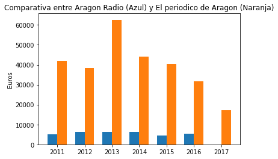

```python
años = ["2011", "2012", "2013", "2014", "2015", "2016", "2017"]
aragon_radio = [4962, 6306, 6306, 6306, 4413, 5328, 0]
aragon_periodico = [41972, 38475, 62613, 43932, 40313, 31710, 17264]

x = np.arange (len(años))

width = 0.35
fig, ax = plt.subplots()

rects1 = ax.bar(x - width/2, aragon_radio, width, label='Aragon Radio')
rects2 = ax.bar(x + width/2, aragon_periodico, width, label='El periodico de Aragón')

ax.set_ylabel ("Euros")
ax.set_title ("Comparativa entre Aragon Radio (Azul) y El periodico de Aragon (Naranja)")
ax.set_xticks(x)
ax.set_xticklabels(años)
```

Vemos una gran diferencia en cuanto a inversión y dimensiones en los distintos medios

```python
plt.savefig("Comparación_grafica-practica-4.png")
```

Lo guardamos y nos aseguramos de que se ha guardado todo correctamente

```python
!ls
```

```
api-pandas-folium.ipynb		    python-prueba.ipynb
Comparación_grafica-practica-4.png  seaborn-data
esvsit.csv			    Shared_Resources
esvsit.png			    Untitled.ipynb
python-api-covid19-pandas.ipynb
```